# Turn Taking Expt 1 Distributional Analysis

# 1 Background

In this study, children and adults answered questions while playing an iPad game. We varied

- Whether the questions’s final word was predicted or not (factor Pred/Unpred).
- Whether the context of the question meant that the length of the final word was predictable or not (factor Match/Mismatcb).
- The interaction of these two factors (i.e., a proper test of whether participants predict during conversation).

In this analysis, we fit hierarchical Bayesian models to characterize the distribution of reaction times

## 1.1 Distribution of Respose Times

The graphs below show the distribution of normaliszed RTs across conditions. When the answer was less predictable, participants were slower to respond. But there was no interaction in the non-distributional analyses.

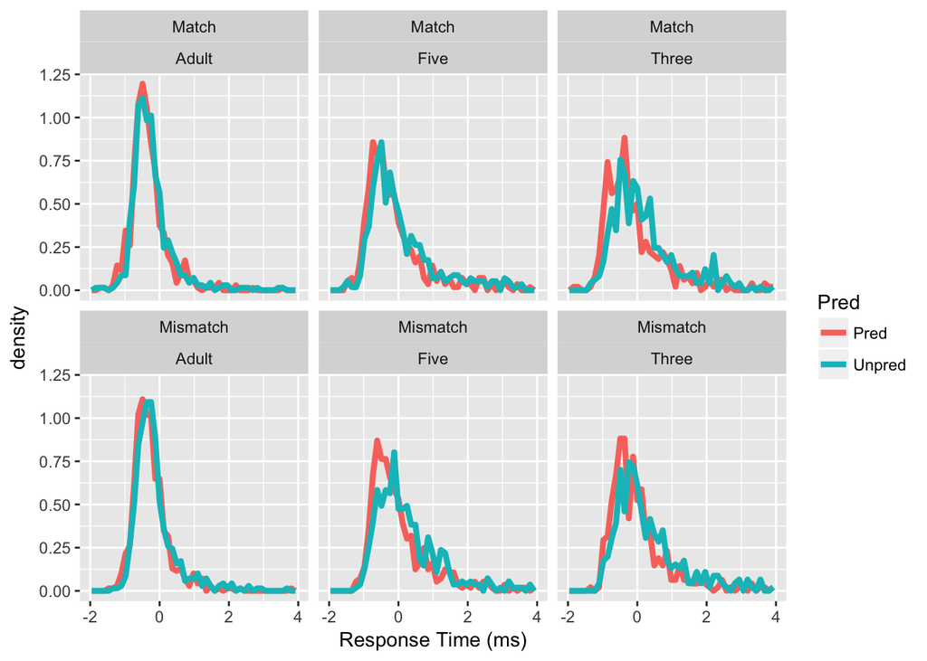

# 2 Analysis

An ex-gaussian distribution convolves a normal distribution with an exponential – this gives it a long and heavy right tail. We aimed to fit an ex-Gaussian to the response time data, comparing adults with children, and hierarchically modeling the mu parameter, the sigma parameter, and the tau parameter. Mu is the mean of the normal and sigma its standard deviation, while tau is the rate of the exponential. We modeled how these varied across conditions, accounting for random subjec intercepts. Informally, our model had the form:

Mu ~ B0 + (B1 * Match) + (B2 * Pred) + (B3 * Age (5)) + (B4 * Age (3)) + … (the full set of interactions) + (1|Subject)  
Sigma ~ B0 + (B1 * Match) + (B2 * Pred) + (B3 * Age (5))+ (B4 * Age (3)) + … (the full set of interactions) + (1|Subject)  
Tau ~ B0 + (B1 * Match) + (B2 * Pred) + (B3 * Age (5)) + (B4 * Age (3)) + … (the full set of interactions) + (1|Subject)

## 2.1 Ex-Gaussian analysis of All ages

```r
all.summary <- summary(eg_stan_exp, pars = c("beta0","beta","beta_s0","beta_s","beta_t0","beta_t"), probs = c(0.025,0.5,0.975))$summary

kable(data.frame("Params" = age_factors,all.summary), digits = 2)
```

|  | Params | mean | se_mean | sd | X2.5. | X50. | X97.5. | n_eff | Rhat |
| --- | --- | --- | --- | --- | --- | --- | --- | --- | --- |
| beta0 | mu_intercept | -0.75 | 0.06 | 0.08 | -0.87 | -0.73 | -0.63 | 1.81 | 2.25 |
| beta[1] | mu_Match | 0.30 | 0.25 | 0.31 | 0.05 | 0.09 | 0.80 | 1.52 | 18.64 |
| beta[2] | mu_Pred | 0.02 | 0.03 | 0.04 | -0.04 | 0.03 | 0.07 | 1.74 | 2.40 |
| beta[3] | mu_Fives | -0.31 | 0.24 | 0.30 | -0.81 | -0.15 | 0.00 | 1.55 | 6.05 |
| beta[4] | mu_Threes | 0.26 | 0.40 | 0.49 | -0.20 | -0.04 | 1.04 | 1.52 | 10.92 |
| beta[5] | mu_MatchByPred | 0.52 | 0.65 | 0.80 | -0.08 | -0.02 | 1.68 | 1.50 | 41.94 |
| beta[6] | mu_MatchByFives | -0.51 | 0.62 | 0.76 | -1.62 | 0.01 | 0.08 | 1.50 | 32.76 |
| beta[7] | mu_MatchByThrees | -0.57 | 0.70 | 0.86 | -1.82 | 0.02 | 0.09 | 1.50 | 35.61 |
| beta[8] | mu_PredByFives | 0.31 | 0.34 | 0.42 | -0.03 | 0.04 | 0.93 | 1.51 | 17.67 |
| beta[9] | mu_PredByThrees | -0.42 | 0.57 | 0.69 | -1.43 | 0.04 | 0.13 | 1.51 | 23.55 |
| beta[10] | mu_MatchByPredByFives | -0.48 | 0.60 | 0.74 | -1.54 | 0.01 | 0.11 | 1.51 | 24.69 |
| beta[11] | mu_MatchByPredByThrees | -0.16 | 0.17 | 0.21 | -0.46 | -0.05 | 0.06 | 1.53 | 6.53 |
| beta_s0 | sig_intercept | -0.88 | 0.70 | 0.86 | -1.62 | -1.43 | 0.56 | 1.52 | 12.33 |
| beta_s[1] | sig_Match | -0.26 | 0.08 | 0.12 | -0.44 | -0.24 | -0.08 | 1.86 | 2.23 |
| beta_s[2] | sig_Pred | 0.59 | 0.67 | 0.82 | -0.11 | 0.04 | 1.77 | 1.51 | 17.28 |
| beta_s[3] | sig_Fives | 0.02 | 0.07 | 0.11 | -0.09 | 0.02 | 0.25 | 2.56 | 1.46 |
| beta_s[4] | sig_Threes | 0.34 | 0.27 | 0.34 | -0.06 | 0.17 | 0.85 | 1.57 | 4.51 |
| beta_s[5] | sig_MatchByPred | -0.01 | 0.08 | 0.12 | -0.24 | -0.02 | 0.12 | 2.08 | 1.77 |
| beta_s[6] | sig_MatchByFives | 0.58 | 0.65 | 0.80 | -0.17 | 0.07 | 1.72 | 1.51 | 10.67 |
| beta_s[7] | sig_MatchByThrees | -0.07 | 0.08 | 0.12 | -0.22 | -0.06 | 0.19 | 2.23 | 1.66 |
| beta_s[8] | sig_PredByFives | -0.52 | 0.68 | 0.83 | -1.70 | 0.00 | 0.25 | 1.51 | 11.06 |
| beta_s[9] | sig_PredByThrees | -0.47 | 0.65 | 0.80 | -1.61 | 0.02 | 0.28 | 1.51 | 10.40 |
| beta_s[10] | sig_MatchByPredByFives | -0.53 | 0.67 | 0.82 | -1.68 | -0.02 | 0.25 | 1.52 | 10.02 |
| beta_s[11] | sig_MatchByPredByThrees | 0.26 | 0.23 | 0.30 | -0.15 | 0.14 | 0.66 | 1.63 | 3.24 |
| beta_t0 | tau_intercept | -0.52 | 0.48 | 0.60 | -1.20 | -0.82 | 0.45 | 1.57 | 4.83 |
| beta_t[1] | tau_Match | -0.67 | 0.63 | 0.77 | -1.76 | -0.19 | 0.04 | 1.51 | 11.11 |
| beta_t[2] | tau_Pred | 0.09 | 0.05 | 0.09 | -0.05 | 0.07 | 0.28 | 3.52 | 1.29 |
| beta_t[3] | tau_Fives | 1.05 | 0.10 | 0.22 | 0.54 | 1.13 | 1.37 | 4.49 | 1.20 |
| beta_t[4] | tau_Threes | 0.33 | 0.85 | 1.06 | -1.16 | 0.93 | 1.43 | 1.53 | 6.73 |
| beta_t[5] | tau_MatchByPred | 0.75 | 0.54 | 0.67 | 0.07 | 0.36 | 1.70 | 1.53 | 7.48 |
| beta_t[6] | tau_MatchByFives | 0.69 | 0.61 | 0.75 | -0.07 | 0.25 | 1.76 | 1.52 | 7.65 |
| beta_t[7] | tau_MatchByThrees | 0.42 | 0.40 | 0.50 | -0.15 | 0.17 | 1.12 | 1.56 | 4.91 |
| beta_t[8] | tau_PredByFives | 0.24 | 0.23 | 0.29 | -0.18 | 0.13 | 0.64 | 1.66 | 2.93 |
| beta_t[9] | tau_PredByThrees | -0.45 | 0.71 | 0.87 | -1.69 | 0.07 | 0.40 | 1.52 | 8.35 |
| beta_t[10] | tau_MatchByPredByFives | 0.50 | 0.81 | 1.00 | -0.52 | -0.07 | 1.90 | 1.52 | 7.72 |
| beta_t[11] | tau_MatchByPredByThrees | -0.55 | 0.56 | 0.69 | -1.51 | -0.22 | 0.27 | 1.56 | 4.75 |

### 2.1.1 Ex Gaussian analysis of Adults alone

```r
no_age_factors <- c("mu_intercept","mu_Match","mu_Pred","mu_MatchByPred",
                    "sig_intercept","sig_Match","sig_Pred","sig_MatchByPred",
                    "tau_intercept","tau_Match","tau_Pred","tau_MatchByPred")

adults.summary <- summary(eg_stan_adults, pars = c("beta0","beta","beta_s0","beta_s","beta_t0","beta_t"), probs = c(0.025,0.5,0.975))$summary

kable(data.frame("Params" = no_age_factors,adults.summary), digits = 2)
```

|  | Params | mean | se_mean | sd | X2.5. | X50. | X97.5. | n_eff | Rhat |
| --- | --- | --- | --- | --- | --- | --- | --- | --- | --- |
| beta0 | mu_intercept | -0.61 | 0.01 | 0.07 | -0.74 | -0.61 | -0.44 | 137.28 | 1.04 |
| beta[1] | mu_Match | 0.06 | 0.00 | 0.02 | 0.02 | 0.06 | 0.10 | 443.40 | 1.01 |
| beta[2] | mu_Pred | 0.03 | 0.00 | 0.02 | -0.01 | 0.03 | 0.07 | 631.58 | 1.00 |
| beta[3] | mu_MatchByPred | -0.03 | 0.00 | 0.02 | -0.08 | -0.03 | 0.01 | 531.23 | 1.00 |
| beta_s0 | sig_intercept | -1.49 | 0.01 | 0.10 | -1.69 | -1.50 | -1.29 | 358.02 | 1.00 |
| beta_s[1] | sig_Match | -0.24 | 0.00 | 0.08 | -0.41 | -0.24 | -0.07 | 395.79 | 1.01 |
| beta_s[2] | sig_Pred | -0.02 | 0.00 | 0.08 | -0.19 | -0.01 | 0.13 | 750.00 | 1.00 |
| beta_s[3] | sig_MatchByPred | -0.11 | 0.00 | 0.11 | -0.32 | -0.11 | 0.09 | 541.25 | 1.00 |
| beta_t0 | tau_intercept | -1.17 | 0.01 | 0.15 | -1.46 | -1.17 | -0.89 | 320.12 | 1.01 |
| beta_t[1] | tau_Match | -0.02 | 0.00 | 0.10 | -0.23 | -0.02 | 0.19 | 572.02 | 1.00 |
| beta_t[2] | tau_Pred | 0.19 | 0.00 | 0.10 | 0.01 | 0.19 | 0.38 | 407.38 | 1.01 |
| beta_t[3] | tau_MatchByPred | 0.21 | 0.01 | 0.13 | -0.02 | 0.21 | 0.48 | 618.12 | 1.00 |

### 2.1.2 Ex Gaussian analysis of Children alone (not broken up by age)

```r
kids.summary <- summary(eg_stan_kids, pars = c("beta0","beta","beta_s0","beta_s","beta_t0","beta_t"), probs = c(0.025,0.5,0.975))$summary

kable(data.frame("Params" = no_age_factors,kids.summary), digits = 2)
```

|  | Params | mean | se_mean | sd | X2.5. | X50. | X97.5. | n_eff | Rhat |
| --- | --- | --- | --- | --- | --- | --- | --- | --- | --- |
| beta0 | mu_intercept | -0.85 | 0.00 | 0.03 | -0.90 | -0.85 | -0.79 | 260.95 | 1.00 |
| beta[1] | mu_Match | 0.13 | 0.00 | 0.03 | 0.08 | 0.13 | 0.18 | 225.39 | 1.00 |
| beta[2] | mu_Pred | 0.10 | 0.00 | 0.03 | 0.05 | 0.10 | 0.15 | 373.52 | 1.00 |
| beta[3] | mu_MatchByPred | -0.02 | 0.00 | 0.03 | -0.09 | -0.02 | 0.05 | 276.71 | 1.00 |
| beta_s0 | sig_intercept | -1.38 | 0.00 | 0.08 | -1.52 | -1.38 | -1.22 | 372.01 | 1.00 |
| beta_s[1] | sig_Match | -0.15 | 0.01 | 0.10 | -0.36 | -0.15 | 0.01 | 346.97 | 1.00 |
| beta_s[2] | sig_Pred | 0.08 | 0.00 | 0.09 | -0.10 | 0.08 | 0.26 | 349.70 | 1.00 |
| beta_s[3] | sig_MatchByPred | 0.04 | 0.01 | 0.12 | -0.17 | 0.03 | 0.33 | 396.07 | 1.00 |
| beta_t0 | tau_intercept | 0.18 | 0.01 | 0.10 | 0.00 | 0.18 | 0.39 | 199.50 | 1.01 |
| beta_t[1] | tau_Match | -0.02 | 0.01 | 0.08 | -0.18 | -0.02 | 0.13 | 234.85 | 1.01 |
| beta_t[2] | tau_Pred | 0.18 | 0.00 | 0.08 | 0.04 | 0.18 | 0.34 | 332.25 | 1.00 |
| beta_t[3] | tau_MatchByPred | 0.11 | 0.01 | 0.10 | -0.10 | 0.11 | 0.33 | 239.85 | 1.01 |